# ch02 - Histogram

2020-05-03T20:10:39+09:00

## Intro

> A picture is worth a thousand words — English Language Adage The simple graph has brought more information to the data analyst’s mind than any other device. — John Tukey

한장의 그림이 수천단어보다 가치가 있다는 영어속담과, 명료한 시각화가 데이터분석가에게 다른 어떤 도구보다 더 많은 정보를 제공한다는 유명한 데이터 과학자의 조언. 핵심은 시각화이다.

본 장에서는 `ggplot2` 패키지를 활용한 시각화를 먼저 보여줄 것이다. 먼저 간단하게 `ggplot2` 패키지에 소개하자면 `Grammar of Graphics`[^1]의 철학을 담아서 `R` 생태계에서 유명한 학자 중, `Hadley Wickham`에 의해 주도적으로 개발되었다. 그래프에도 문법이 있다는 패키지의 철학 아래, `R`의 시각화는 괄목할만한 발전을 이루었고 이는 `R`의 대중화에도 큰 영향을 끼쳤다.

이제 본격적으로 `R` 시각화를 작성해보자.

## I. 사전준비

본 장에서는 시각화를 위해서 `ggplot2`를 주요 패키지로 사용한다. `ggplot2` 패키지를 설치했다고 가정한다. 만약 처음 패키지를 설치하는 사람이라면 [R 패키지 설치](https://wikidocs.net/58057)[^2]에서 다시 한번 R 패키지 주요 생태계에 대해 이해하도록 한다.

Studio를 열고 아래 코드를 실행하자:

```r
library(ggplot2)
```

`library(ggplot2)`를 실행하면 `Registered ~`라는 문구가 나왔다면 컴퓨터내 시스템에서 `RStudio` 환경으로 `ggplot2` 패키지를 정상적으로 불러왔다는 뜻이다. 이제 패키지 내 다양한 함수를 사용할 수 있는 사전준비가 완료된 것으로 이해해도 좋다.

## II. 데이터셋 - 텍사스 부동산 판매데이터

대한민국에서 가장 중요한 문제중의 하나인 부동산과 관련하여 시각화를 진행하려 한다. 지금은 `ggplot2` 패키지 내에 존재하는 텍사스 부동산 판매데이터를 통해 시각화를 진행하지만, 향후에는 국내 부동산 데이터를 직접 가져와서 시각화를 진행하기를 바란다.

`txhousing` 데이터는 총 `8602`개의 관측치와 `9`개의 변수로 구성이 되어 있다. `txhousing` 데이터의 출처 및 각 변수(`Column`)에 대해 조금 더 자세히 알고 싶다면 `R` 소스코드 에디터에서 help(`txhousing`)을 실행하여 도움말을 참고하기를 바란다.

## III. ggplot2 with Histogram

히스토그램은 언제 그려야 할까?

산점도 그래프가 두개의 연속형 변수를 통해서 변수간의 관계를 파악하는 그래프라고 한다면, 히스토그램은 연속형 변수 1개를 활용하여 각 변수마다 고유의 분포를 보여주고 싶을 때 작성한다. `txhousing` 데이터에서 sales 변수를 가지고 데이터를 작성하도록 해보자.

우선 아래코드를 실행 후 결과를 확인해보자.

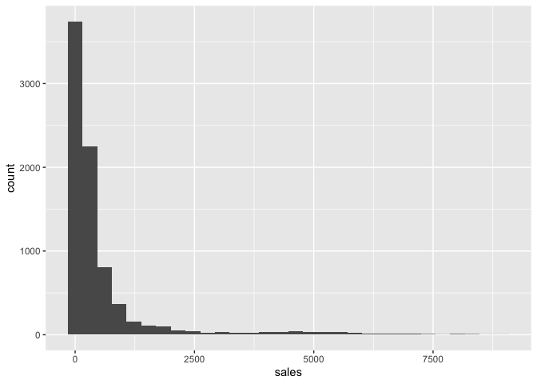

```r
ggplot(data = txhousing, aes(x = sales)) +
  geom_histogram()
```

위 그래프를 보면, 데이터가 오른쪽으로 꼬리모양 형태를 띠며 분포하고 있는 것을 그리고 있다. 특히, sales 값 중 > 7500 이상 되는 값도 눈에 띄는데, 이것을 통계적인 용어로 이상치(outlier)라고 부른다.

그런데, 이상치는 평균을 한쪽으로 치우치게 만들 뿐 아니라 표준편차를 부풀릴 뿐만 아니라 표준편차를 근간으로 하는 모든 통계적인 모델링에 악영향을 미친다.

### (1) Add Color and fill

히스토그램의 대략적인 기능을 이해했다면, 이제 본격적으로 시각화에 집중해본다. 색상을 입혀보자.

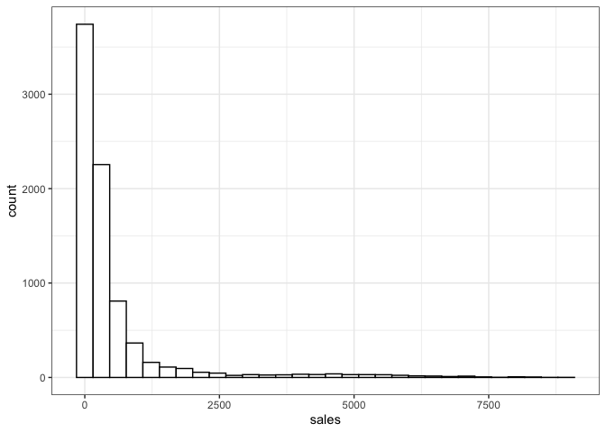

```r
ggplot(data = txhousing, aes(x = sales)) +
  geom_histogram(color = "black", fill = "white") +
  theme_bw()
```

### (2) X축에 평균선을 그려보자.

- 평균선을 그리려면, `geom_vline()` 함수를 추가해야 한다.

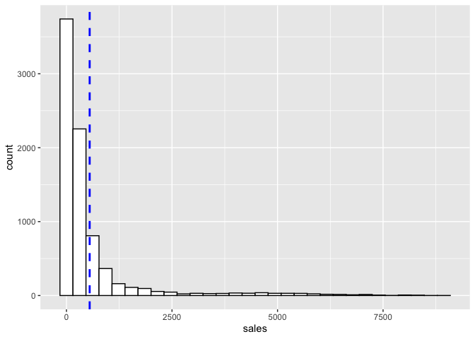

```r
ggplot(data = txhousing, aes(x = sales)) +
  geom_histogram(color = "black", fill = "white") +
  geom_vline(aes(xintercept=mean(sales, na.rm = TRUE)),
             color = "blue", linetype="dashed", size=1)
```

- line types의 종류에는,`“blank”, “solid”, “dashed”, “dotted”, “dotdash”, “longdash”, “twodash”`가 있다.

### (3) Change Plot Colors by groups

우선 `dplyr` 패키지를 활용하여 월별 평균을 구해본다.

```r
library(dplyr)
txhousing %>%
  group_by(month) %>%
  summarise(grp.mean = mean(sales, na.rm = TRUE))
```

```
## # A tibble: 12 x 2
##    month grp.mean
##    <int>    <dbl>
##  1     1     357.
##  2     2     431.
##  3     3     563.
##  4     4     578.
##  5     5     650.
##  6     6     685.
##  7     7     666.
##  8     8     648.
##  9     9     530.
## 10    10     516.
## 11    11     462.
## 12    12     504.
```

- 이번에는 `data.table`을 활용하여 평균을 구해본다.

```r
library(data.table)
txhousing2 <- data.table(txhousing)
txhousing2[, .(Mean=mean(sales, na.rm = TRUE)), by = month]
```

```
##     month     Mean
##  1:     1 356.9289
##  2:     2 430.8285
##  3:     3 563.1863
##  4:     4 577.5174
##  5:     5 649.7366
##  6:     6 685.1188
##  7:     7 665.8299
##  8:     8 647.8975
##  9:     9 529.6961
## 10:    10 516.3344
## 11:    11 462.0295
## 12:    12 504.4146
```

- 위 방법 중 마음에 드는 것을 선택해 `mean_sales`라고 저장한다.

```r
library(dplyr)
txhousing %>%
  group_by(month) %>%
  summarise(grp.mean = mean(sales, na.rm = TRUE)) -> mean_sales
head(mean_sales)
```

```
## # A tibble: 6 x 2
##   month grp.mean
##   <int>    <dbl>
## 1     1     357.
## 2     2     431.
## 3     3     563.
## 4     4     578.
## 5     5     650.
## 6     6     685.
```

이 때, 1월과 7월을 비교하는 그래프를 그려본다.

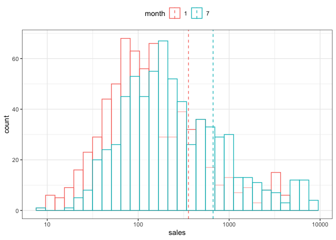

```r
jan_jul <- txhousing %>%
  filter(month %in% c(1, 7)) %>%
  mutate(month = as.character(month))
mean_jan_jul <- mean_sales %>%
  filter(month %in% c(1,7)) %>%
  mutate(month = as.character(month))

ggplot(jan_jul, aes(x=sales, color=month)) +
  geom_histogram(fill='white', alpha=.5, position = "identity") +
  geom_vline(data = mean_jan_jul,
             aes(xintercept=grp.mean, color=month),
             linetype='dashed') +
  scale_x_log10() +
  theme_bw() +
  theme(legend.position="top")
```

- 먼저, `geom_vline(new_data, ~)`함수 안에 새로운 데이터를 추가해서 작성하는 것도 가능하다.
- `scale_x_log10()`을 추가하였는데, 로그변환을 통해서 정규변환 형태로 만든 이후에 그래프를 비교하면 보다 시각적으로 비교하는 데 용이하다.
- 위와 같이 1월과 7월별로 히스토그램으로도 충분히 그래프를 비교할 수 있다.
- 또하나의 미션을 주겠다. 전체 평균 데이터셋을 구해서 `geom_vline()`함수를 추가해보자.